# Lecture 16

## Data Processing and Analysis

- So far, we have learned algorithms of traditional computational mathemitcs
- These algorithms provide a foundation for most computational work
- Now, we move on to explore data proessing and analysis, statitics, and statistical modeling
- As a first step, we learn about the standard Python data analysis library: **pandas**

### Pandas

- provide high-performance, easy-to-use data structures and data analysis tools for the Python programming language
- **pandas** library builds on top of **numpy** and complements it with features that are particularly useful when handling data
- **pandas** has become the *de facto* standard library for data processing in python,especially for statistics applications.

### Key features that Pandas library provide

- labeled indexing
- hierarchical indices
- alignment of data for comparison
- merging of datasets
- handling of missing data
- and much more

Pandas library provide only limited support for statistical modeling (i.e., linear regression) For more involved statistical analysis and modeling, people use the following the libraries:

- statsmodel
- patsy
- scikit-learn

While using these packages for statistical analysis and modeling, **pandas** can still be used for data representation and preparation.

**Pandas** library is the key component in the software stack for data analysis with Python

### This lecture

Introduce basic features and usage of the **pandas** library

```python
# import module
import pandas as pd
# for some examples, we also need numpy and matplotlib
import numpy as np
import matplotlib.pyplot as plt
```

**pandas** library mainly provides data structures and methods for representing and manipulating data

### Two main data structure of pandas are the following objects

- **Series**: represent data series
- **DataFrame**: represent tabular data

## Series

```python
s=pd.Series([90997,8615264,2872086,2273305])
```

```python
s
```

```
0      90997
1    8615264
2    2872086
3    2273305
dtype: int64
```

here object s is a Series instance with the data type **int64**

```python
# exctract index and value
s.index
```

```
RangeIndex(start=0, stop=4, step=1)
```

```python
s.values
```

```
array([  90997, 8615264, 2872086, 2273305])
```

Using integer indecis is functional, but not descriptive. For example, if the values represnts the population of four cities. It is more descriptive to use city name as the index.

```python
s.index=["Stockholm","London","Rome","Paris"]
s.name="Population"
```

```python
s
```

```
Stockholm      90997
London       8615264
Rome         2872086
Paris        2273305
Name: Population, dtype: int64
```

Now, it is more obvious what the data represents

Alternatively, we can pass all the information to the contructor while creating the data object

```python
s=pd.Series([90997,8615264,2872086,2273305],name="Population",index=["Stockholm","London","Rome","Paris"])
```

```python
s
```

```
Stockholm      90997
London       8615264
Rome         2872086
Paris        2273305
Name: Population, dtype: int64
```

Ways to access data

```python
s["London"]
```

```
8615264
```

```python
s.Stockholm
```

```
90997
```

```python
s[["Paris","Rome"]]
```

```
Paris    2273305
Rome     2872086
Name: Population, dtype: int64
```

with data represented in Series object, we can easily compute its **descriptive statistics** using the following methods:

- **count**: the number of data points
- **std**: the standard deviation
- **mean**: the mean value
- **median**: the median
- **min** (**max**): min/max values
- **qunatile**: calculating the qunatiles

```python
s.median(),s.mean(),s.std()
```

```
(2572695.5, 3462913.0, 3636884.292717692)
```

```python
s.min(),s.max()
```

```
(90997, 8615264)
```

```python
s.quantile(q=0.25),s.quantile(q=0.5),s.quantile(q=0.75)
```

```
(1727728.0, 2572695.5, 4307880.5)
```

```python
s.sort_values() # we can sort the values
```

```
Stockholm      90997
Paris        2273305
Rome         2872086
London       8615264
Name: Population, dtype: int64
```

```python
s.sort_index() # we cal also sort the index
```

```
London       8615264
Paris        2273305
Rome         2872086
Stockholm      90997
Name: Population, dtype: int64
```

We can use **describe** method to out all the aformentioned statistical values

```python
s.describe()
```

```
count    4.000000e+00
mean     3.462913e+06
std      3.636884e+06
min      9.099700e+04
25%      1.727728e+06
50%      2.572696e+06
75%      4.307880e+06
max      8.615264e+06
Name: Population, dtype: float64
```

Using plot method we can quickly visualize the data

```python
# we select a style that is suitable for statistical graphs
import matplotlib as mpl
mpl.style.use('ggplot')
```

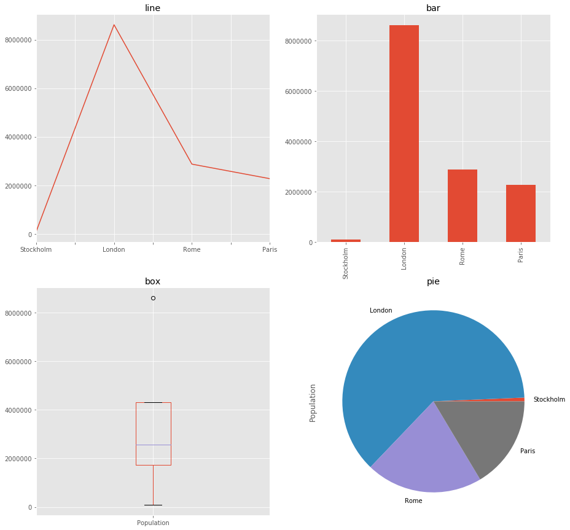

```python
fig,axes=plt.subplots(2,2,figsize=(15,15))
s.plot(ax=axes[0,0],kind='line',title='line')
s.plot(ax=axes[0,1],kind='bar',title='bar')
s.plot(ax=axes[1,0],kind='box',title='box')
s.plot(ax=axes[1,1],kind='pie',title='pie')

plt.show()
```